# Psycholingwistyka

Agata Zywert

18 maja 2018

`Na początku jest historia o małpach co gadają, wybaczcie, ale to pominę :)`

### Percepcja i wytwarzanie mowy

#### Mózgowa reprezentacja mowy

- Obszar mowy - obszar wokół bruzdy bocznej (bruzdy Sylwiusza)
- ośrodek ruchowy mowy
- ośrodek czuciowy mowy
- pęczek łukowaty `im not sure`
- część wzgórza związana z percepcją słuchową
- pierwotna kora słuchowa

##### **Dwie najbardziej znane i kojarzone z mową okolice kory mózgu to:**

- **ośrodek Broki** (część wieczkowa i trójkątna zakrętu czołowego dolnego), odpowiedzialny za generowanie ruchów umożliwiających wytwarzanie mowy,
- **ośrodek Wernickego** (tylna część zakrętu skroniowego górnego), obejmujący mechanizmy rozumienia znaczenia poszczególnych słów.

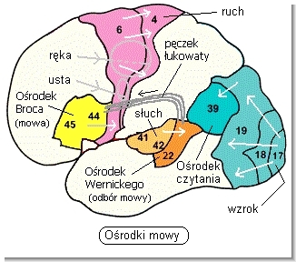

##### **Zróżnicowanie brzmieniowe**

- **średnio 6 samogłosek**
  - min. 2 -Yimas, Papua New Guinea
  - max. 14-niemiecki
- **średnio 22 spółgłoski**
  - min. 6-Rotokas, Papua New Guinea
  - max. 122 (!Xoo, Botswana)

##### **Interpretacja fonemów**

- zmienność brzmieniowa wynikająca z koartykulacji
- zmienność brzmieniowa wynikająca z różnic międzyosobniczych
- zdolność wyodrębniania słów

##### **Percepcja mowy**

- 10-30 fonemów na sekundę
- samogłoski
- spółgłoski
- koartykulacja
- transmisja paralelna
- zmienność allofoniczna
- przewaga prawego ucha? `mnie pytasz Emila?`

##### **Spektrograf akustyczny**

##### Spektogramdźwiękowy – obraz wytwarzany przez spektrograf

- częstotliwość (y)
- czas (x)
- amplituda (zaczernienie)

### **Percepcja mowy a percepcja wzrokowa**

#### **SYGNAŁ DŹWIĘKOWY** -> <- **WIEDZA JĘZYKOWA**

##### **Komunikaty zawierające niedoskonałe / wieloznaczne sygnały?**

- **Przetwarzanie zstępujące (top-down)**
  - informacja leksykalna
  - informacja syntaktyczna
  - informacja kontekstowa
- **Przetwarzanie wstępujące (bottom-up)**
  - tylko informacja akustyczna

##### **Współdziałanie wstępującego i zstępującego przetwarzania mowy**

- zjawisko odzyskiwania fonemu (ang. phonemicrestoration)
- rozpoznawanie błędów mowy
  - sekwencje typowe > atypowe
  - błędne miejsce artykulacji > zmiana dźwięczności
  - spółgłoski nagłosowe > wygłosowe

##### **Modele percepcji mowy**

- **akustyczne sygnały mowy a segmenty fonetyczne?**
- motoryczna teoria percepcji mowy
- teoria analizy przez syntezę
- model logiki zbiorów rozmytych akustyczne sygnały mowy a słuchowe rozpoznawanie słów?
- **modele interakcyjne**
- model kohortowy
- model TRACE

##### **Motoryczna teoria percepcji mowy**

- odbiór mowy zgodny z mechanizmami jej wytwarzania
- sygnały interpretowane przez odwołanie się do motoryki ruchów artykulacyjnych
- wyjaśnia problem: sygnał akustyczny a reprezentacja fonematyczna
- niezmienniki na poziomie realizacji artykulacyjnej?
- Problemy kliniczne: AFAZJA a APRAKSJA MOWY

##### **Analiza przez syntezę**

- związek między percepcją mowy a jej wytwarzaniem
- rozumienie dzięki wykorzystaniu matryc abstrakcyjnych cech dystynktywnych
- odbiór mowy (analiza) –wewnętrzna synteza –porównanie wyniku syntezy z bodźcem słuchowym
- rozumienie mowy jako proces weryfikacji hipotez
- model abstrakcyjny
- weryfikacja empiryczna? `proszę przestań zadawać mi pytania...`
1. Model logiki zbiorów rozmytych (ang. fuzzylogicalmodel)
- **Percepcja mowy obejmuje 3 operacje:**
  - **ocenę cech** (stopnia dopasowania cech do prototypu)
  - **integrację cech**
  - **podjęcie decyzji** (na podst. względnej zgodności egzemplarza z prototypem)
- **PROTOTYPY** – sumaryczne opisy percepcyjnych jednostek języka, zawierające połączenie różnych cech dystynktywnych
- cechy prototypu odpowiadają wartościom idealnym, które powinien mieć każdy egzemplarz
- różne cechy fonemu odpowiadające danemu kontrastowo fonetycznemu wydobywane są niezależnie z fali głosowej
- cechy te są łączone zgodnie z zasadami integracji logicznej (bazującymi na rozmytych wartościach logicznych), informacja dotycząca cechy może być reprezentowana jako stopień dopasowania
- informacja ma postać ciągła, a nie dyskretną
- proces probabilistyczny
2. **Model kohortowy**
- aktywacja kohorty słów -akustyczno-fonetyczna forma słowa aktywizuje wszystkie słowa o tym samym początku (słowa te tworzą kohortę)
- selekcja słowa z kohorty (na podst. informacji akustycznej, ale również semantycznej, częstości użycia wyrazu)
3. **Model TRACE**
- odwołanie do działania sieci neuronowych
- przetwarzanie informacji poprzez pobudzające i hamujące połączenia między węzłami
- **cechy węzła:**
  - poziom spoczynkowy
  - próg pobudzenia
  - poziom aktywacji, który określa stopień w jakim informacja wejściowa jest zgodna z jednostką reprezentowaną przez ten węzeł
- sieć powiązań między węzłami
- powiązania dwukierunkowe między węzłami

##### Neurobiologiczna organizacja percepcji słuchowej

- Ciała kolankowate przyśrodkowe
- Zakręty poprzeczne Heschla
4. **Model dwustrumieniowy percepcji mowy** (Hickoki Poeppel, 2000, 2004, 2007)
- rozwinięcie modelu Wernicke’go-Geschwinda-Lichtheima
- strumień brzuszny–skroniowo-czołowy
- przetwarzanie dźwięku w znaczenie (powiązanie systemu fonologicznego z leksykalno-semantycznym)
- strumień grzbietowy–ciemieniowo-czołowy
- przetwarzanie dźwięku w działanie (powiązanie systemu fonologicznego z ruchowo-artykulacyjnym)
- w percepcji mowy uczestniczą obie półkule mózgu
- każda z półkul ma nieco inne okno czasowe dla percepcji mowy

##### **Dowody potwierdzające model dwustrumieniowy percepcji mowy w zakresie zaangażowania obupółkulowegow proces percepcji mowy**

- badania z użyciem fMRIosób zdrowych
- badania z zastosowaniem próby Wady
- badania osób z afazją Wernicke’go
- badania osób z czystą głuchotą słowną

##### **Sieć fonologiczna**

- Boczna część zakrętu skroniowego górnego
- Środkowa część bruzdy skroniowej górnej
- Obupółkulowo
- Zróżnicowanie ze względu na unikatowość brzmieniową słowa
- phonologicalneighbourhooddensity–gęstość sąsiedztwa fonologicznego
- Czym więcej podobnych słów tym większa aktywność mózgu podczas percepcji danego słowa

##### **Prawa półkula**

- Rozpoznawanie samogłosek
- Rozpoznawanie głosu

##### **Próba Wady**

- Niewielka ilość błędów
- Głównie błędy semantyczne

##### **Czysta głuchota słowna** (ang. pureworddeafness) - U ok. 72% pacjentów uszkodzenia obupółkuloweśrodkowej i tylnej części górnego zakrętu skroniowego oraz istoty białej, z oszczędzeniem zakrętów Heschla

##### **Hipoteza asymetrycznego próbkowania**

- lewa półkula –szybkie kontrasty fonemiczne
- prawa półkula –informacje sylabowe

##### **Percepcja fonemów i dźwięków, które nie są fonemami**

- Percepcja kategorialna
- Przewaga lewej półkuli

##### **Efekt McGurka**

- Ba (audio) –ga(wideo) –da
- Rozbieżność między sygnałem akustycznym i wzrokowym
- TMS ukierunkowana na zakręt skroniowy górny zmniejsza efekt McGurkaale tylko 100ms przed / po ekspozycji
- Tylna część lewego górnego zakrętu skroniowego : integracja informacji słuchowej i wzrokowej w percepcji mowy

##### **Badania elektrofizjologiczne percepcji mowy –Abrams i wsp., 2008**

- Prawa półkula
- Lewa półkula

#### **Wczesne dowody wspierające model dwustrumieniowy** - podwójna dysocjacja między rozumieniem a powtarzaniem

#### **Rozumienie słów a rozróżnianie fonemów**

- Dopasowywanie słowoobrazek
- Różnicowanie fonemów (takie same –inne)
- Interfejs leksykalny (przetwarzanie struktur fonologicznych w semantyczne lub „lemma”)
- Sieć kombinatoryczna

##### **Interfejs leksykalny**

- tylna część środkowego zakrętu skroniowego po lewej
- tylna część dolnego zakrętu skroniowego obupółkulowo, ale w większym stopniu po lewej

#### **Sieć kombinatoryczna**

- przednia część lewego płata skroniowego, powierzchnia boczna
- rozumienie słów w zdaniach
- Badanie Rogalskyi Hickoka:
- Zdania poprawne (te same w 2 warunkach), błędne (20%) -wykrywanie nieprawidłowości semantycznych
- e.g., The infant was spilling some carpet on the milk -wykrywanie nieprawidłowości składniowych
- e.g., The plumber with the glasses were installing the sink
- analiza wzorca aktywacji mózgowej w przypadku zdań prawidłowych, takich samych –w warunku semantycznym i syntaktycznym

#### Planumtemporale - strumień grzbietowy - słuchowe „jak”

#### **reprezentacje percepcyjne -> <- reprezentacje ruchowe**